# Regresión Lineal Simple - Clase 2

Cecilia Oliva

06/06/2023

# Modelo lineal

## Transformación de variables

### Ejemplo

Analizamos los datos de provisión de investigación y docencia universitaria en 62 universidades en Reino Unido en 1988.

Consideramos las siguientes variables para construir un modelo lineal:

nassets: activos netos,

stfees: cuotas de los estudiantes.

```r
#install.packages("Ecdat")
library(Ecdat)
data(University)
head(University)
```

|  | undstudents | poststudents | nassets | acnumbers | acrelnum | clernum | compop | techn | stfees | acpay | acrelpay | secrpay | admpay | agresrk | furneq | landbuild | resgr |
| --- | --- | --- | --- | --- | --- | --- | --- | --- | --- | --- | --- | --- | --- | --- | --- | --- | --- |
| 1 | 17 | 1190 | 3669.71 | 183.0 | 50 | 127.0 | 1.0 | 15.0 | 2821 | 4889 | 0 | 683 | 954 | 915.000 | 143 | 2674 | 2176 |
| 2 | 0 | 392 | 12156.00 | 83.0 | 62 | 32.0 | 4.0 | 15.0 | 4037 | 993 | 110 | 457 | 1001 | 410.000 | 392 | 9063 | 1502 |
| 3 | 9752 | 3975 | 185203.00 | 2030.0 | 658 | 845.5 | 27.5 | 633.5 | 17296 | 30705 | 9273 | 8667 | 4705 | 9147.090 | 6229 | 44888 | 40746 |
| 4 | 10035 | 3376 | 323100.00 | 2008.0 | 412 | 800.0 | 200.0 | 440.0 | 18800 | 31840 | 10478 | 5650 | 2592 | 8962.760 | 9400 | 18307 | 30300 |
| 5 | 2556 | 1569 | 32154.00 | 345.5 | 81 | 278.0 | 7.0 | 15.0 | 9314 | 10292 | 0 | 1645 | 1931 | 1518.400 | 829 | 16838 | 2075 |
| 6 | 5813 | 1134 | 41669.00 | 897.0 | 181 | 405.0 | 9.5 | 156.5 | 7388 | 15636 | 2530 | 1852 | 2126 | 3732.425 | 2094 | 42089 | 11352 |

```r
dim(University)
```

```
## [1] 62 17
```

```r
linMod <- lm(nassets ~ stfees, data = University)
summary(linMod)
```

```
##
## Call:
## lm(formula = nassets ~ stfees, data = University)
##
## Residuals:
##    Min     1Q Median     3Q    Max
## -70529 -20410  -5350  11948 244354
##
## Coefficients:
##               Estimate Std. Error t value Pr(>|t|)
## (Intercept) -36446.662  12078.934  -3.017  0.00374 **
## stfees          12.957      1.472   8.802 2.13e-12 ***
## ---
## Signif. codes:  0 '***' 0.001 '**' 0.01 '*' 0.05 '.' 0.1 ' ' 1
##
## Residual standard error: 48450 on 60 degrees of freedom
## Multiple R-squared:  0.5636, Adjusted R-squared:  0.5563
## F-statistic: 77.48 on 1 and 60 DF,  p-value: 2.126e-12
```

```r
cor(University$nassets,University$stfees)^2# Observar que coincide con R^2 del modelo linMod
```

```
## [1] 0.5635741
```

```r
library(car)
library(lmtest)
```

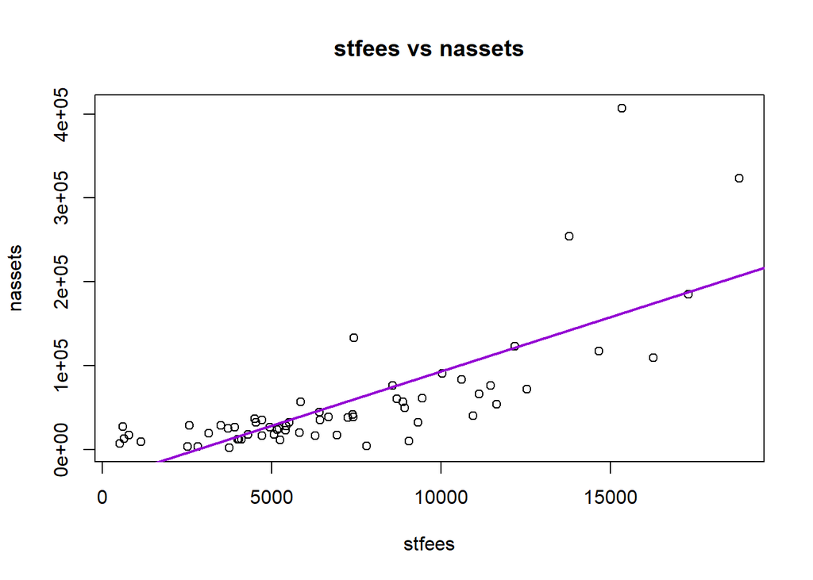

```r
plot(University$stfees,University$nassets,xlab="stfees",ylab="nassets",
     main="stfees vs nassets")

abline(linMod,col="darkviolet",lwd=2)
```

### Analizamos normalidad, homocedasticidad y no autocorrelación de los residuos.

```r
shapiro.test(linMod$residuals)
```

```
##
##  Shapiro-Wilk normality test
##
## data:  linMod$residuals
## W = 0.79217, p-value = 6.024e-08
```

```r
bptest(linMod)
```

```
##
##  studentized Breusch-Pagan test
##
## data:  linMod
## BP = 9.8244, df = 1, p-value = 0.001722
```

```r
dwt(linMod)
```

```
##  lag Autocorrelation D-W Statistic p-value
##    1      -0.1159196      2.209462   0.408
##  Alternative hypothesis: rho != 0
```

Se rechaza normalidad y homocedasticidad.

### Transformaciones de Box y Cox

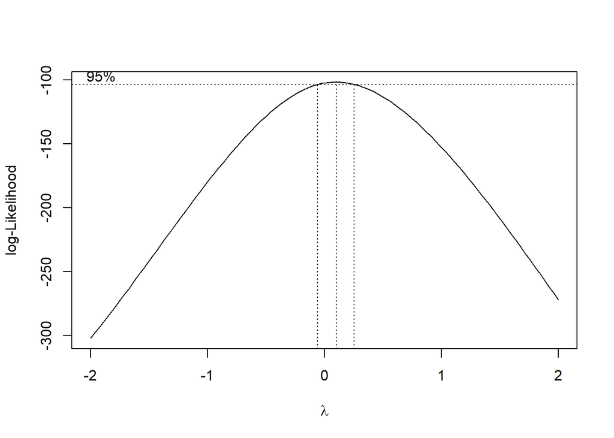

```r
library(MASS)
boxcox(nassets ~ stfees, lambda = -2:2, data = University)
```

Observemos que, según el gráfico, el lambda óptimo se encuentra cerca de 0. Entonces consideraremos la transformación logarítmica sobre la variable respuesta.

```r
linMod2 <- lm(log10(nassets) ~ stfees, data = University)
summary(linMod2)
```

```
##
## Call:
## lm(formula = log10(nassets) ~ stfees, data = University)
##
## Residuals:
##      Min       1Q   Median       3Q      Max
## -0.92640 -0.10585  0.05163  0.17629  0.58772
##
## Coefficients:
##              Estimate Std. Error t value Pr(>|t|)
## (Intercept) 3.915e+00  7.281e-02  53.765  < 2e-16 ***
## stfees      8.361e-05  8.873e-06   9.423 1.93e-13 ***
## ---
## Signif. codes:  0 '***' 0.001 '**' 0.01 '*' 0.05 '.' 0.1 ' ' 1
##
## Residual standard error: 0.2921 on 60 degrees of freedom
## Multiple R-squared:  0.5967, Adjusted R-squared:   0.59
## F-statistic: 88.78 on 1 and 60 DF,  p-value: 1.934e-13
```

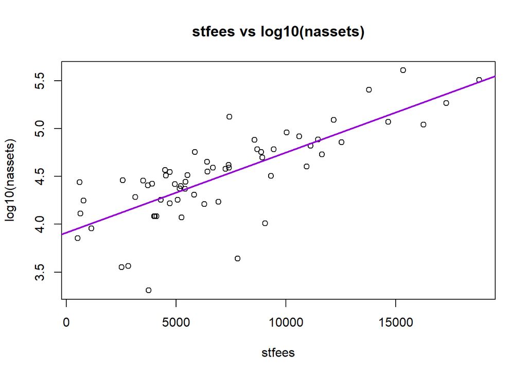

```r
plot(University$stfees,log10(University$nassets),xlab="stfees",ylab="log10(nassets)",
     main="stfees vs log10(nassets)")

abline(linMod2,col="darkviolet",lwd=2)
```

Realizamos el análisis diagnóstico.

```r
shapiro.test(linMod2$residuals)
```

```
##
##  Shapiro-Wilk normality test
##
## data:  linMod2$residuals
## W = 0.91401, p-value = 0.0003535
```

```r
bptest(linMod2)
```

```
##
##  studentized Breusch-Pagan test
##
## data:  linMod2
## BP = 0.71582, df = 1, p-value = 0.3975
```

```r
dwt(linMod2)
```

```
##  lag Autocorrelation D-W Statistic p-value
##    1      -0.1692912      2.227608    0.39
##  Alternative hypothesis: rho != 0
```

En este caso se vuelve a rechazar normalidad de los residuos. Probamos aplicar la transformación logarítmica a la covariable stfees, y rehacemos el gráfico de Box y Cox.

```r
linMod2a<- lm(nassets ~ log10(stfees), data = University)
summary(linMod2a)
```

```
##
## Call:
## lm(formula = nassets ~ log10(stfees), data = University)
##
## Residuals:
##    Min     1Q Median     3Q    Max
## -68472 -27892 -20446    -22 301617
##
## Coefficients:
##               Estimate Std. Error t value Pr(>|t|)
## (Intercept)    -373992      87626  -4.268 7.12e-05 ***
## log10(stfees)   114426      23276   4.916 7.18e-06 ***
## ---
## Signif. codes:  0 '***' 0.001 '**' 0.01 '*' 0.05 '.' 0.1 ' ' 1
##
## Residual standard error: 61930 on 60 degrees of freedom
## Multiple R-squared:  0.2871, Adjusted R-squared:  0.2753
## F-statistic: 24.17 on 1 and 60 DF,  p-value: 7.182e-06
```

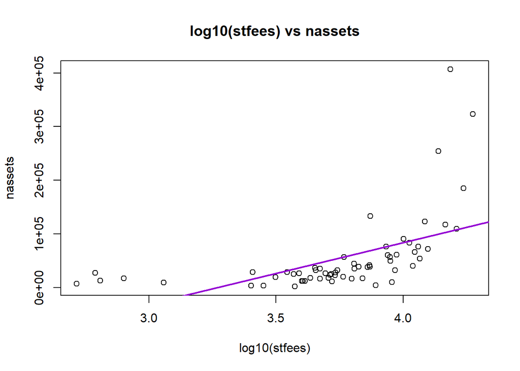

```r
plot(log10(University$stfees),University$nassets,xlab="log10(stfees)",ylab="nassets",
     main="log10(stfees) vs nassets")

abline(linMod2a,col="darkviolet",lwd=2)
```

Realizamos el análisis diagnóstico.

```r
shapiro.test(linMod2a$residuals)
```

```
##
##  Shapiro-Wilk normality test
##
## data:  linMod2a$residuals
## W = 0.67143, p-value = 1.673e-10
```

```r
bptest(linMod2a)
```

```
##
##  studentized Breusch-Pagan test
##
## data:  linMod2a
## BP = 3.0721, df = 1, p-value = 0.07965
```

```r
dwt(linMod2a)
```

```
##  lag Autocorrelation D-W Statistic p-value
##    1     -0.08744916      2.144092   0.612
##  Alternative hypothesis: rho != 0
```

En este caso se rechaza normalidad, analizamos si se puede aplicar una transformación de Box y Cox conveniente.

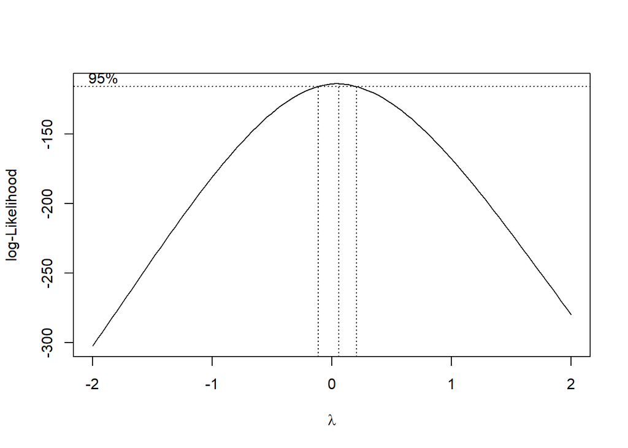

```r
boxcox(nassets ~ log10(stfees), lambda = -2:2, data = University)#lambda cerca de 0
```

Nuevamente, el gráfico sugiere aplicar a la variable respuesta la transformación logarítmica.

```r
linMod3 <- lm(log10(nassets) ~ log10(stfees), data = University)
summary(linMod3)
```

```
##
## Call:
## lm(formula = log10(nassets) ~ log10(stfees), data = University)
##
## Residuals:
##      Min       1Q   Median       3Q      Max
## -1.04465 -0.15024  0.03523  0.16945  0.76327
##
## Coefficients:
##               Estimate Std. Error t value Pr(>|t|)
## (Intercept)     1.2722     0.4980   2.555   0.0132 *
## log10(stfees)   0.8622     0.1323   6.519 1.65e-08 ***
## ---
## Signif. codes:  0 '***' 0.001 '**' 0.01 '*' 0.05 '.' 0.1 ' ' 1
##
## Residual standard error: 0.3519 on 60 degrees of freedom
## Multiple R-squared:  0.4146, Adjusted R-squared:  0.4048
## F-statistic: 42.49 on 1 and 60 DF,  p-value: 1.647e-08
```

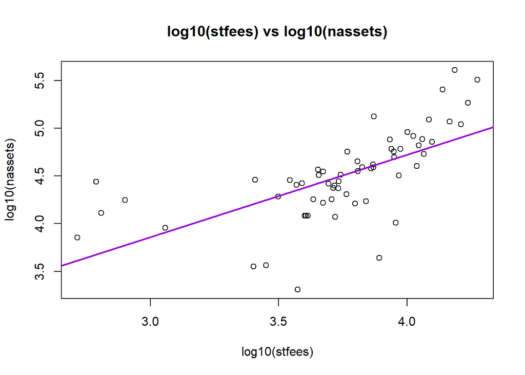

```r
plot(log10(University$stfees),log10(University$nassets),xlab="log10(stfees)",ylab="log10(nassets)",
     main="log10(stfees) vs log10(nassets)")

abline(linMod3,col="darkviolet",lwd=2)
```

Evaluamos normalidad, homocedasticidad y no autocorrelación de residuos.

```r
shapiro.test(linMod3$residuals)
```

```
##
##  Shapiro-Wilk normality test
##
## data:  linMod3$residuals
## W = 0.94897, p-value = 0.01191
```

```r
bptest(linMod3)
```

```
##
##  studentized Breusch-Pagan test
##
## data:  linMod3
## BP = 0.9545, df = 1, p-value = 0.3286
```

```r
dwt(linMod3)
```

```
##  lag Autocorrelation D-W Statistic p-value
##    1      -0.2767975      2.412478   0.118
##  Alternative hypothesis: rho != 0
```

A nivel 1% no se rechaza normalidad de los residuos, y se mantiene la homocedasticidad y la no autocorrelación de los mismos.

## Intervalos de confianza y de predicción

Graficamos ambas bandas de confianza y predicción para el modelo original.

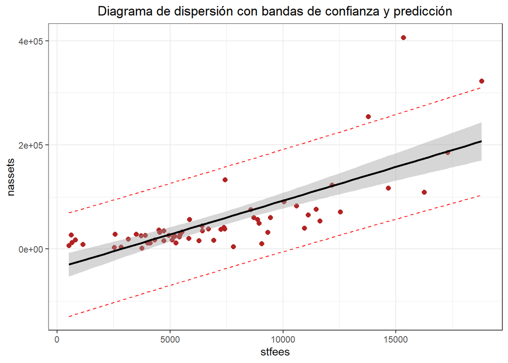

```r
ICcompleto<-predict(linMod, interval="confidence",level=0.95)
IPcompleto<-predict(linMod,newdata=data.frame(stfees=University$stfees), interval="prediction",level=0.95)
datos<-data.frame(stfees=University$stfees,nassets=University$nassets,IPcompleto)

library(ggplot2)
ggplot(data = datos, mapping = aes(x = stfees, y = nassets)) +
  geom_point(color = "firebrick", size = 2) +
  labs(title = "Diagrama de dispersión con bandas de confianza y predicción", x = "stfees") +
  geom_line(aes(y=lwr), color="red" , linetype="dashed" ) +
  geom_line(aes(y=upr), color="red" , linetype="dashed" ) +
  geom_smooth(method = "lm", se = TRUE, color = "black") +
  theme_bw() + theme(plot.title = element_text(hjust = 0.5))
```

```r
# geom_smooth por defecto incluye la región de 95% de confianza.
```

Analizamos ambos tipos de intervalos en todos los modelos probados cuando stfees=10000.

```r
IC<-predict(linMod,newdata=data.frame(stfees=10000),interval="confidence")
IP<-predict(linMod,newdata=data.frame(stfees=10000),interval="prediction")

IC
```

```
##        fit      lwr    upr
## 1 93123.44 78076.84 108170
```

```r
IP
```

```
##        fit       lwr    upr
## 1 93123.44 -4960.103 191207
```

```r
IC2<-predict(linMod2,newdata=data.frame(stfees=10000),interval="confidence")
IP2<-predict(linMod2,newdata=data.frame(stfees=10000),interval="prediction")

IC2
```

```
##        fit      lwr      upr
## 1 4.750884 4.660182 4.841586
```

```r
IP2
```

```
##        fit      lwr      upr
## 1 4.750884 4.159631 5.342137
```

```r
IC3<-predict(linMod3,newdata=data.frame(stfees=10000),interval="confidence")#OJO:NO poner log10(10000)
IP3<-predict(linMod3,newdata=data.frame(stfees=10000),interval="prediction")#OJO:NO poner log10(10000)

IC3
```

```
##        fit      lwr      upr
## 1 4.721169 4.609877 4.832462
```

```r
IP3
```

```
##        fit      lwr      upr
## 1 4.721169 4.008488 5.433851
```

```r
10^IC3
```

```
##        fit     lwr      upr
## 1 52622.26 40726.5 67992.62
```

```r
10^IP3
```

```
##        fit      lwr      upr
## 1 52622.26 10197.37 271550.5
```

Observemos que el intervalo de confianza siempre está contenido en el intervalo de predicción, por lo tanto la longitud de IC es menor que la de IP.

Por otro lado, a continuación verificamos con el gráfico (haciendo zoom en stfees=10000) que es más correcta la predicción del modelo linMod3 que la de linMod.

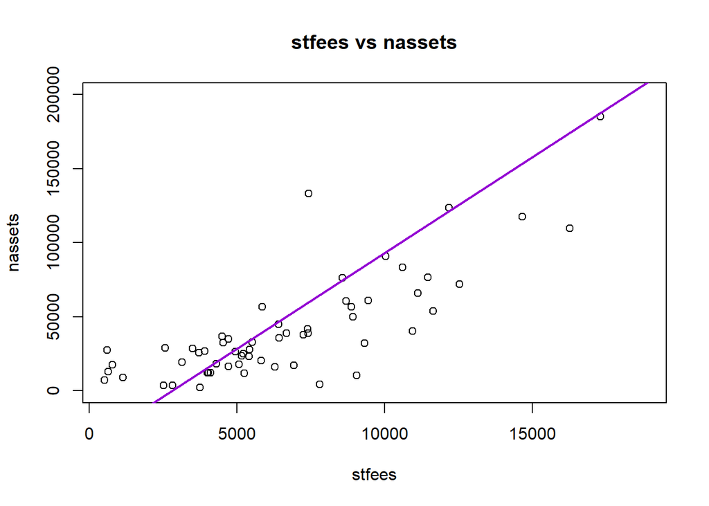

```r
plot(University$stfees,University$nassets,xlab="stfees",ylab="nassets",
     main="stfees vs nassets",ylim=c(0,200000))

abline(linMod,col="darkviolet",lwd=2)
```

Se puede ver que es más coherente para stfees cercano a 10000, un nassets cercano a 50000 más que a 90000 como sugiere la recta de regresión de linMod.

## Outliers, puntos influyentes, y de alto leverage

### Análisis de residuos y residuos estudentizados

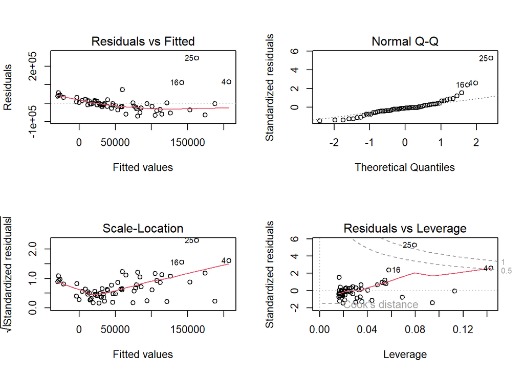

```r
par(mfrow=c(2,2))
plot(linMod)
```

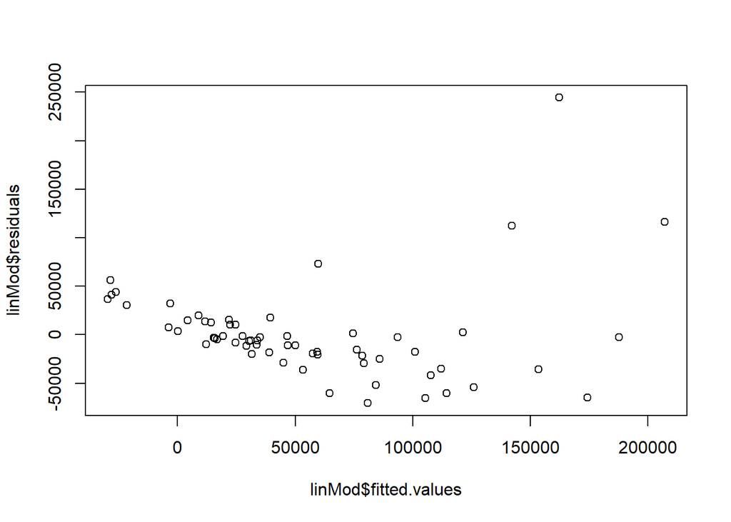

```r
par(mfrow=c(1,1))
plot(linMod$fitted.values,linMod$residuals)
```

```r
#plot(linMod3)

res_stu_1<-rstudent(linMod)
res_stu_1[abs(res_stu_1)>3]
```

```
##      25
## 7.09442
```

### Otros puntos influyentes: dfbetas y dffits

```r
influence.measures(model = linMod)
```

```
## Influence measures of
##   lm(formula = nassets ~ stfees, data = University) :
##
##       dfb.1_  dfb.stfs    dffit cov.r   cook.d    hat inf
## 1   0.013240 -0.009715  0.01364 1.069 9.46e-05 0.0327
## 2  -0.011174  0.007141 -0.01218 1.060 7.55e-05 0.0246
## 3   0.011487 -0.017607 -0.01902 1.166 1.84e-04 0.1128   *
## 4  -0.711636  1.047956  1.11242 0.953 5.59e-01 0.1433   *
## 5  -0.006383 -0.075245 -0.15861 1.015 1.25e-02 0.0208
## 6  -0.020595 -0.003643 -0.04672 1.047 1.11e-03 0.0162
## 7   0.037895 -0.100662 -0.13885 1.051 9.71e-03 0.0340
## 8  -0.046409  0.022723 -0.05740 1.048 1.67e-03 0.0191
## 9   0.092074 -0.195134 -0.24543 1.035 3.00e-02 0.0438
## 10  0.145438 -0.119169  0.14591 1.072 1.07e-02 0.0484
## 11 -0.014421  0.007168 -0.01771 1.054 1.60e-04 0.0193
```

[output cut: 51 more lines]

```r
summary(influence.measures(model = linMod))
```

```
## Potentially influential observations of
##   lm(formula = nassets ~ stfees, data = University) :
##
##    dfb.1_  dfb.stfs dffit   cov.r   cook.d  hat
## 3   0.01   -0.02    -0.02    1.17_*  0.00    0.11_*
## 4  -0.71    1.05_*   1.11_*  0.95    0.56    0.14_*
## 16 -0.28    0.52     0.62_*  0.90_*  0.17    0.06
## 25 -1.12_*  1.86_*   2.08_*  0.33_*  1.19_*  0.08
```

```r
dfbetas(linMod)[,2]> 1
```

```
##     1     2     3     4     5     6     7     8     9    10    11    12    13
## FALSE FALSE FALSE  TRUE FALSE FALSE FALSE FALSE FALSE FALSE FALSE FALSE FALSE
##    14    15    16    17    18    19    20    21    22    23    24    25    26
## FALSE FALSE FALSE FALSE FALSE FALSE FALSE FALSE FALSE FALSE FALSE  TRUE FALSE
##    27    28    29    30    31    32    33    34    35    36    37    38    39
## FALSE FALSE FALSE FALSE FALSE FALSE FALSE FALSE FALSE FALSE FALSE FALSE FALSE
##    40    41    42    43    44    45    46    47    48    49    50    51    52
## FALSE FALSE FALSE FALSE FALSE FALSE FALSE FALSE FALSE FALSE FALSE FALSE FALSE
##    53    54    55    56    57    58    59    60    61    62
## FALSE FALSE FALSE FALSE FALSE FALSE FALSE FALSE FALSE FALSE
```

```r
which(dfbetas(linMod)[,2]>1)
```

```
##  4 25
##  4 25
```

```r
n<-length(University$nassets)
p<-length(linMod$coefficients)
which(dffits(linMod)>2 * sqrt(p / n))
```

```
##  4 16 25
##  4 16 25
```

### Otros puntos influyentes: puntos de alto leverage y distancia de Cook

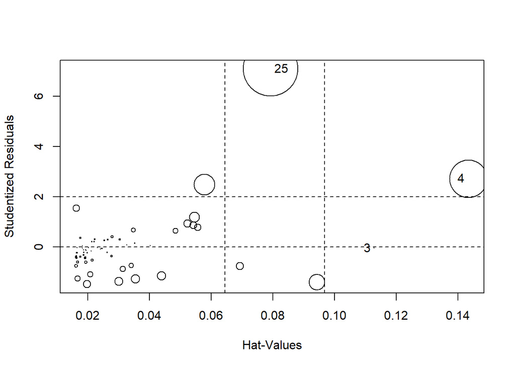

|  | StudRes | Hat | CookD |
| --- | --- | --- | --- |
| 3 | -0.05333795 | 0.11280736 | 0.0001839248 |
| 4 | 2.71986446 | 0.14330826 | 0.5591259089 |
| 25 | 7.09441957 | 0.07926379 | 1.1889185711 |

```r
influencePlot(model = linMod)
```

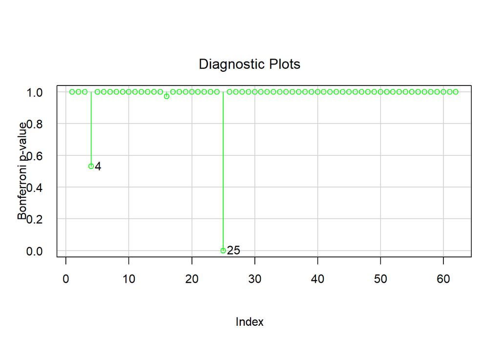

```r
influenceIndexPlot(linMod, vars='Bonf', las=1,col='green')
```

```r
hatvalues(linMod)
```

```
##          1          2          3          4          5          6          7
## 0.03272105 0.02456889 0.11280736 0.14330826 0.02081351 0.01622769 0.03399610
##          8          9         10         11         12         13         14
## 0.01912606 0.04384378 0.04844133 0.01928784 0.01935273 0.02118703 0.01823322
##         15         16         17         18         19         20         21
## 0.03512688 0.05781780 0.09420903 0.01616339 0.02135653 0.01625885 0.02768767
##         22         23         24         25         26         27         28
## 0.06932325 0.03002965 0.01669348 0.07926379 0.01651902 0.02433004 0.01748037
##         29         30         31         32         33         34         35
## 0.02626523 0.05234230 0.01858125 0.02027322 0.05412109 0.02220127 0.01914906
##         36         37         38         39         40         41         42
## 0.04023703 0.01864484 0.01614611 0.01650123 0.01947142 0.01755737 0.03131901
##         43         44         45         46         47         48         49
## 0.01974372 0.01861416 0.02531595 0.01624206 0.03028220 0.03543718 0.01832078
##         50         51         52         53         54         55         56
## 0.02200404 0.02645575 0.01625948 0.02476538 0.03477678 0.02781932 0.02310876
##         57         58         59         60         61         62
## 0.02121299 0.01977631 0.05561586 0.02415544 0.01663162 0.05447720
```

```r
outlierTest(linMod)
```

```
##    rstudent unadjusted p-value Bonferroni p
## 25  7.09442         1.8723e-09   1.1608e-07
```

```r
#leverage
hatvalues(linMod)
```

```
##          1          2          3          4          5          6          7
## 0.03272105 0.02456889 0.11280736 0.14330826 0.02081351 0.01622769 0.03399610
##          8          9         10         11         12         13         14
## 0.01912606 0.04384378 0.04844133 0.01928784 0.01935273 0.02118703 0.01823322
##         15         16         17         18         19         20         21
## 0.03512688 0.05781780 0.09420903 0.01616339 0.02135653 0.01625885 0.02768767
##         22         23         24         25         26         27         28
## 0.06932325 0.03002965 0.01669348 0.07926379 0.01651902 0.02433004 0.01748037
##         29         30         31         32         33         34         35
## 0.02626523 0.05234230 0.01858125 0.02027322 0.05412109 0.02220127 0.01914906
##         36         37         38         39         40         41         42
## 0.04023703 0.01864484 0.01614611 0.01650123 0.01947142 0.01755737 0.03131901
##         43         44         45         46         47         48         49
## 0.01974372 0.01861416 0.02531595 0.01624206 0.03028220 0.03543718 0.01832078
##         50         51         52         53         54         55         56
## 0.02200404 0.02645575 0.01625948 0.02476538 0.03477678 0.02781932 0.02310876
##         57         58         59         60         61         62
## 0.02121299 0.01977631 0.05561586 0.02415544 0.01663162 0.05447720
```

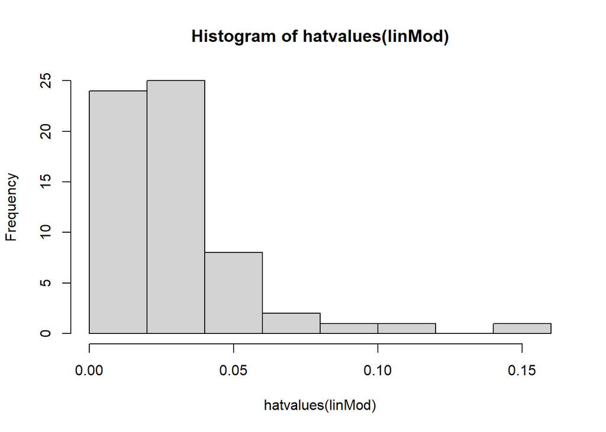

```r
hist(hatvalues(linMod))
```

```r
lev<-hatvalues(linMod)

#un criterio (mayores que 0.2)

which(lev>0.2)
```

```
## named integer(0)
```

```r
#un criterio mas exigente
n<-length(University$nassets)
p<-length(linMod$coefficients)
which(lev>2*p/n)
```

```
##  3  4 17 22 25
##  3  4 17 22 25
```

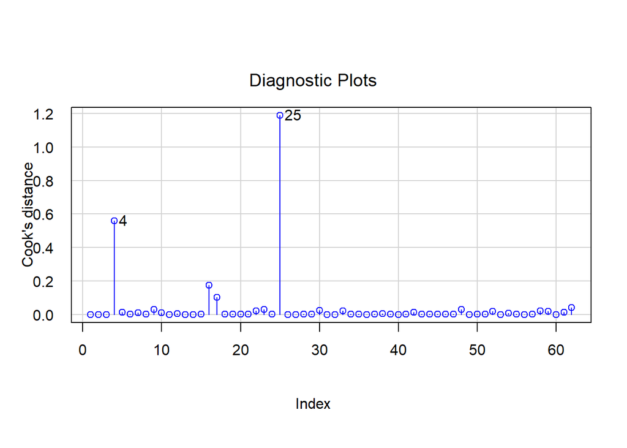

```r
#distancias de cook
dcook<-cooks.distance(linMod)
influenceIndexPlot(linMod, vars='Cook', las=1,col='blue')
```

```r
which(dcook>4/n)
```

```
##  4 16 17 25
##  4 16 17 25
```

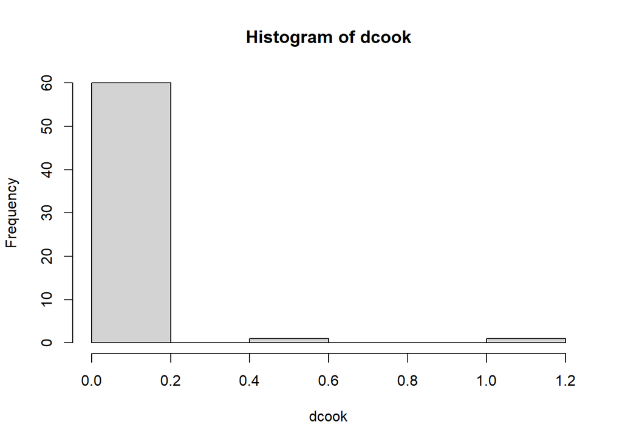

```r
hist(dcook)
```

```r
#punto de corte
corted<-qf(0.5,2,n-2)
which(dcook>corted)
```

```
## 25
## 25
```

## Cuadrados mínimos ponderados

Construimos dos vectores de pesos para evaluar cuadrados mínimos ponderados.

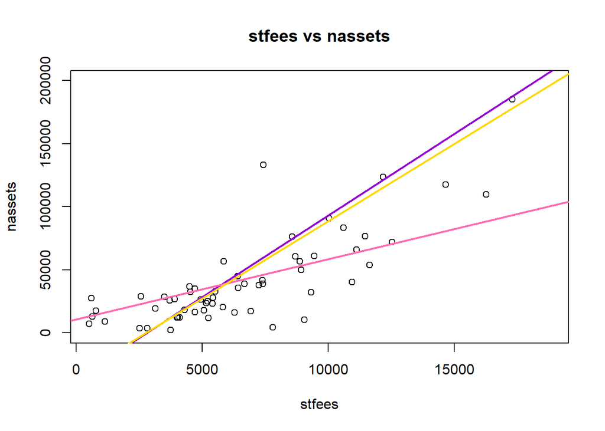

```r
ww<-1 / lm(abs(linMod$residuals) ~ linMod$fitted.values)$fitted.values^2
www<-1 / (abs(linMod$residuals))#^2


plot(University$stfees,University$nassets,xlab="stfees",ylab="nassets",
     main="stfees vs nassets", ylim=c(0,200000))

abline(linMod,col="darkviolet",lwd=2)

linMod_ww<- lm(nassets ~ stfees, data = University,weights =ww)
linMod_www<- lm(nassets ~ stfees, data = University,weights =www)
abline(linMod_ww,col="hotpink",lwd=2)
abline(linMod_www,col="gold",lwd=2)
```